# Project 2 Preliminary Report

## Group Members

Specify the names and EIDs of all group members (if not working in a group just put your own name and EID): Stephanie Kuo sk59344 Tony Huang tkh699 Annika Shivam aes5956

## Dataset

Identify the dataset you plan to work with (provide a link to it if possible if it is not one of the suggested datasets): We will be working with the Austin Animal Center Intakes dataset.

## Question

Specify the question you plan to ask/answer with this dataset: Can we predict whether an animal arrives in healthy (Normal) condition based on animal type, intake type, sex upon intake, and age upon intake?

## Outcome Variable

What is the outcome variable in your dataset that you will be predicting? **For the purposes of this project, the outcome should either be continuous or binary**. The outcome variable we will be predicting is the “Intake Condition.” We will code this into a binary variable (1 = Healthy (Normal), 0 = Unhealthy (all other conditions)).

## Outcome Summary

Provide a summary plot of the outcome variable. For example, if it is a continuous variable, show a histogram or a boxplot. If it is a binary variable, show a barplot.

```r
library(tidyverse)
## renaming dataset to something shorter -> "Animal_Intakes"
Animal_Intakes <- read_csv("Austin_Animal_Center_Intakes_20250407.csv.gz")
```

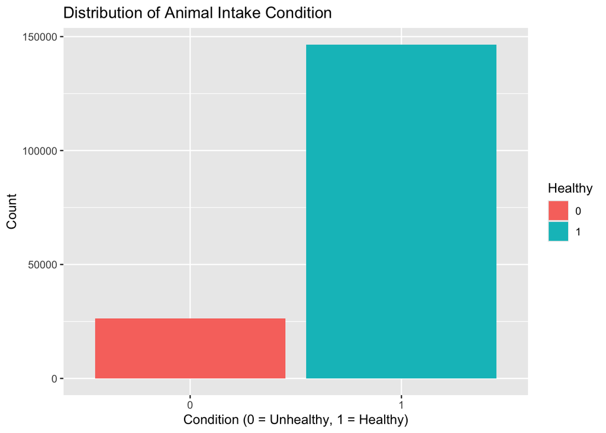

```r
# Recode outcome as binary
Animal_Intakes <- Animal_Intakes |>
    mutate(Healthy = factor(ifelse(`Intake Condition` == "Normal", 1, 0)))

# Summary barplot of outcome variable
Animal_Intakes |>
    ggplot(aes(x = Healthy, fill = Healthy)) +
    geom_bar() +
    labs(title = "Distribution of Animal Intake Condition",
         x = "Condition (0 = Unhealthy, 1 = Healthy)",
         y = "Count")
```

## Submission to Gradescope

**Make sure to add your group members to the Gradescope submission!**